# Classification – red wine or white wine?

```
## [1] "Dimension of red wine data set: 1599, 13"
```

```
## [1] "Dimension of red wine data set: 4898, 13"
```

The dimension of red wine data set is (1599, 13), and the dimension of white wine data set is (4898, 13). The white wine data set is nearly three times that of the red wine data set – the data set is imbalanced.

## Distribution of Potential Predictors

This part contains some exploratory data analysis on the wine quality data set, mainly for the purpose of classifying read wine and white wine. First we would like to explore the distribution of all the potential predictors separately for red wine and white wine, to see if there is any difference between predictor distribution in two groups.

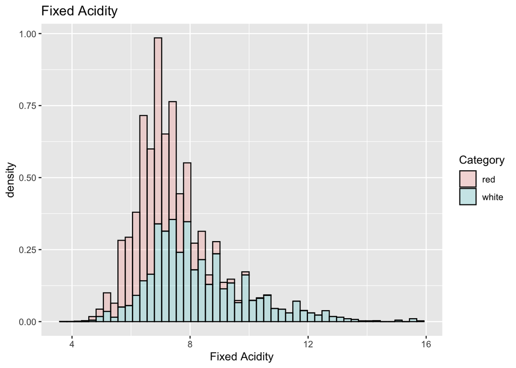

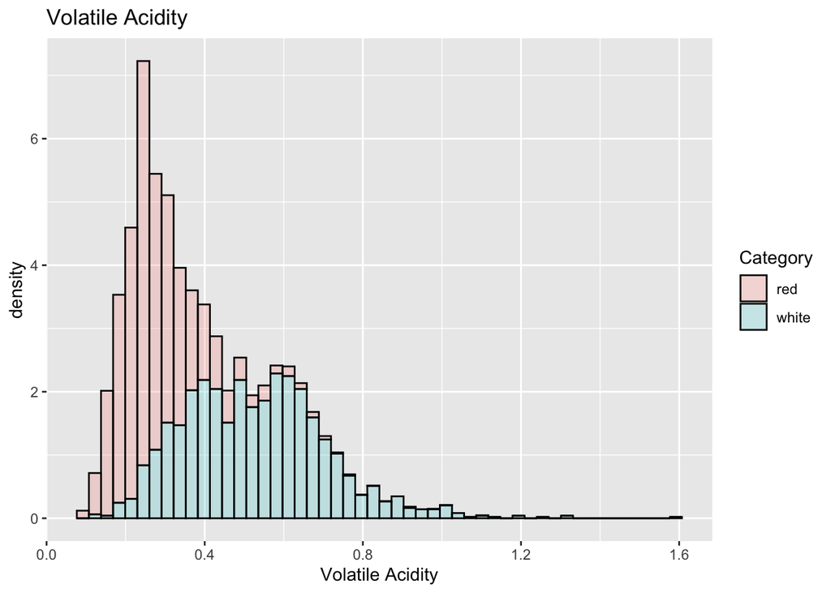

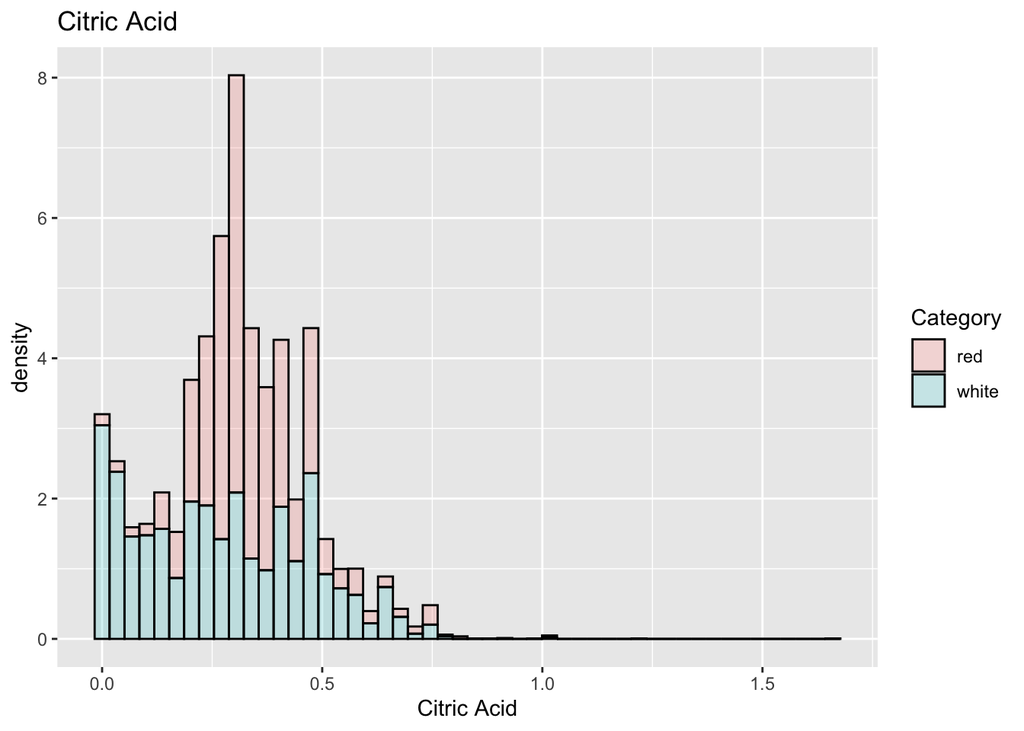

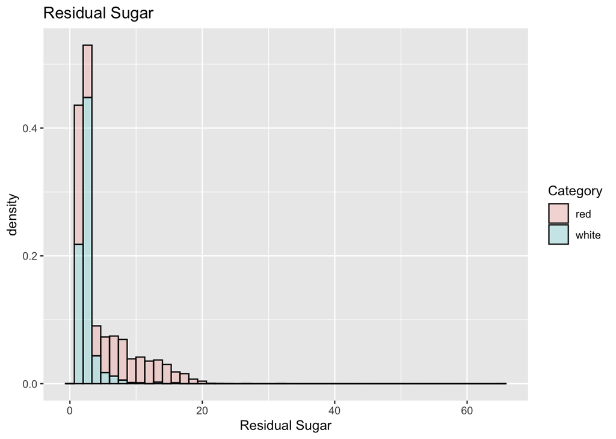

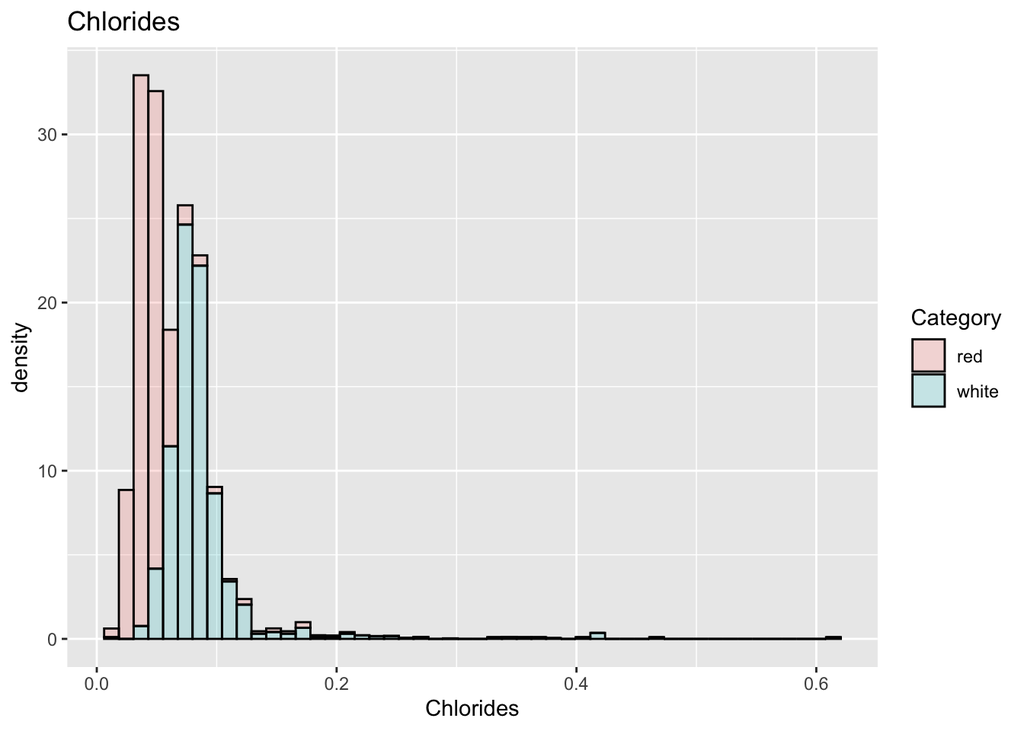

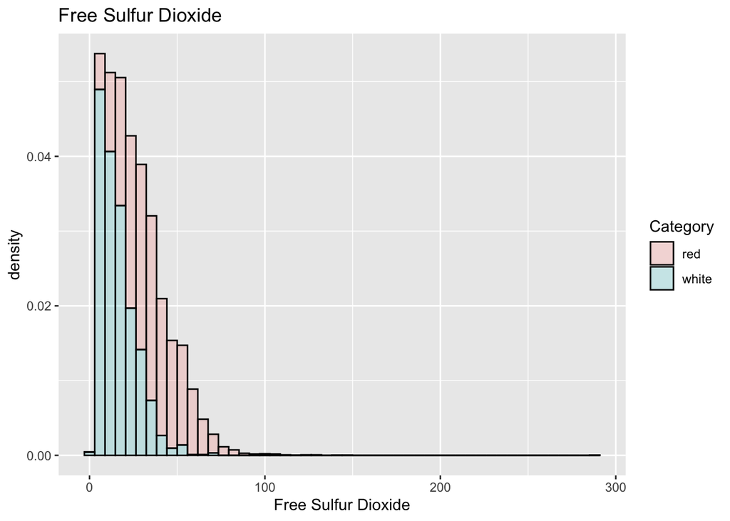

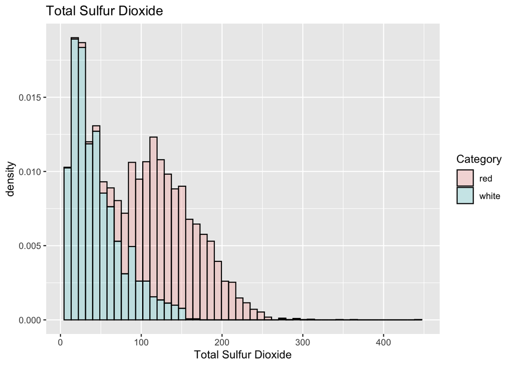

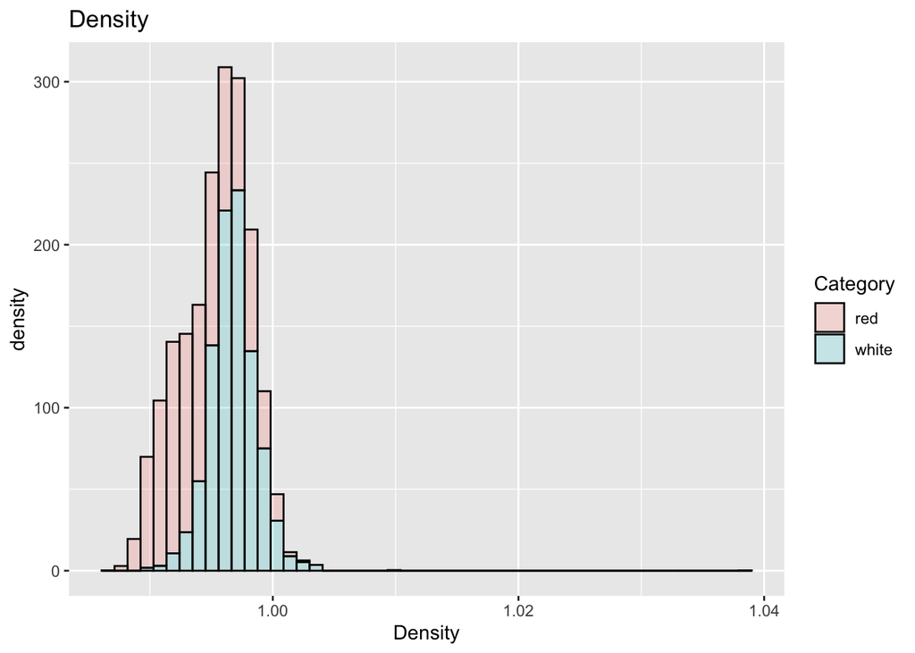